# ISL_Chapter8

Michael Rose

October 14, 2017

## Fitting Regression Trees

We will be fitting a regression tree to the Boston data set.

```r
# reproducibility
set.seed(1)
# create training set
train <- sample(1:nrow(Boston), nrow(Boston)/2)
tree.boston <- tree(medv~., Boston, subset=train)
summary(tree.boston)
```

```
##
## Regression tree:
## tree(formula = medv ~ ., data = Boston, subset = train)
## Variables actually used in tree construction:
## [1] "lstat" "rm"    "dis"
## Number of terminal nodes:  8
## Residual mean deviance:  12.65 = 3099 / 245
## Distribution of residuals:
##      Min.   1st Qu.    Median      Mean   3rd Qu.      Max.
## -14.10000  -2.04200  -0.05357   0.00000   1.96000  12.60000
```

Our output above indicates that 3 of the variables have been used in constructing the tree, lstat, rm, and dis. In the context of trees, the deviance is the sum of squared errors for the tree.

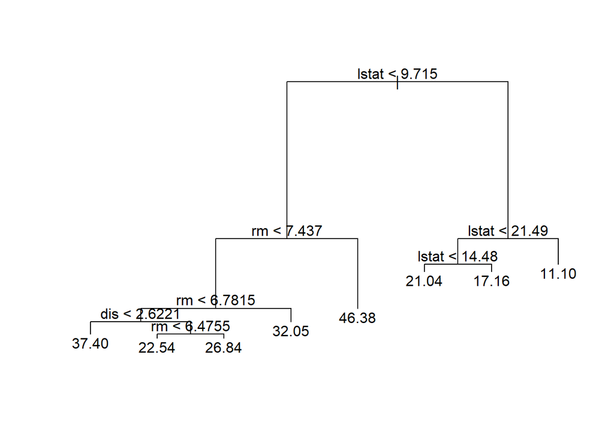

```r
plot(tree.boston)
text(tree.boston, pretty=0)
```

The variable lstat measures the percentage of individuals with lower socioeconomic status. The tree indicates that lower values of lstat correspond to more expensive houses.

The tree predicts a median house price of $46,400 for larger homes in suburbs in which residents have high socioeconomic status (lstat < 9.715 and rm >= 7.437).

Lets see if pruning the tree will increase performance.

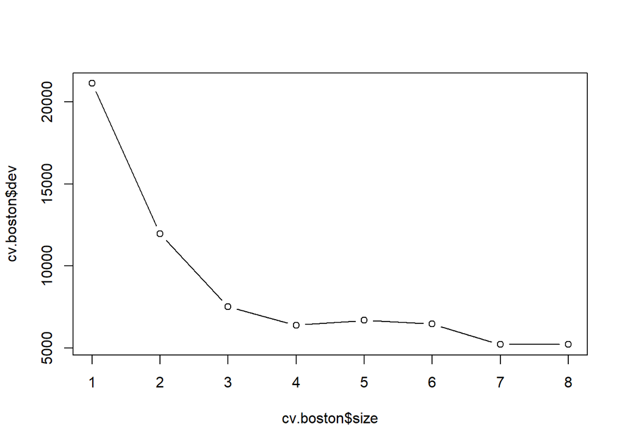

```r
cv.boston <- cv.tree(tree.boston)
plot(cv.boston$size, cv.boston$dev, type='b')
```

In this case, cross validation has selected the most complex tree. We can still prune the tree if we wish to though:

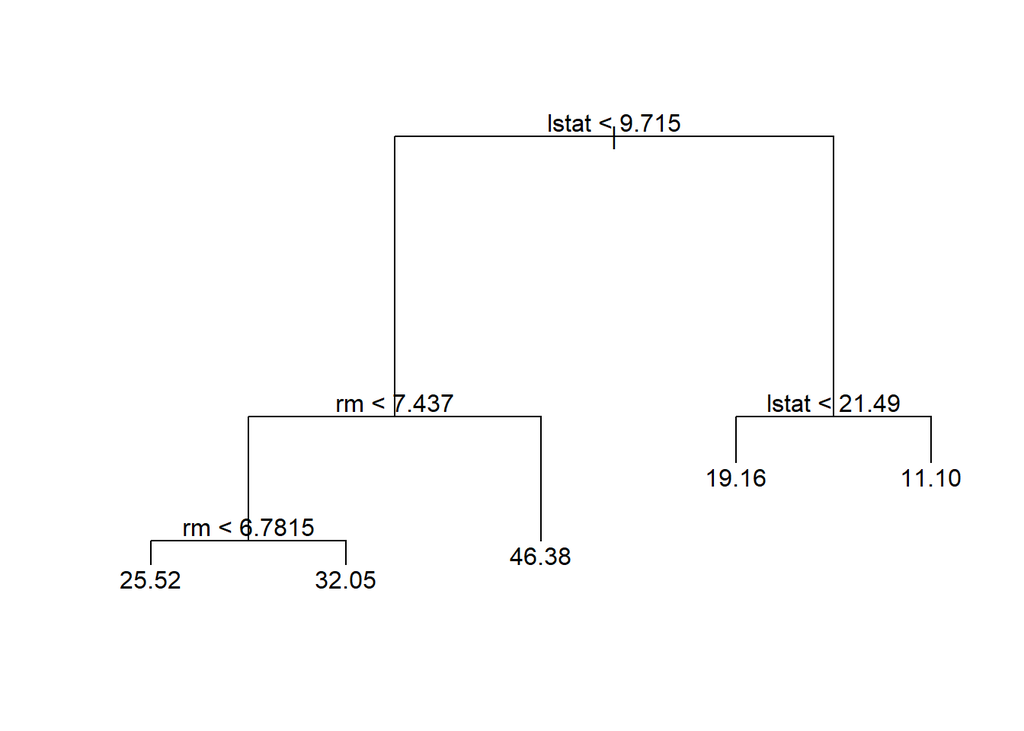

```r
prune.boston <- prune.tree(tree.boston, best=5)
plot(prune.boston)
text(prune.boston, pretty=0)
```

This looks much better. In keeping with our cross validation results, we use the unpruned tree to make predictions on the test set.

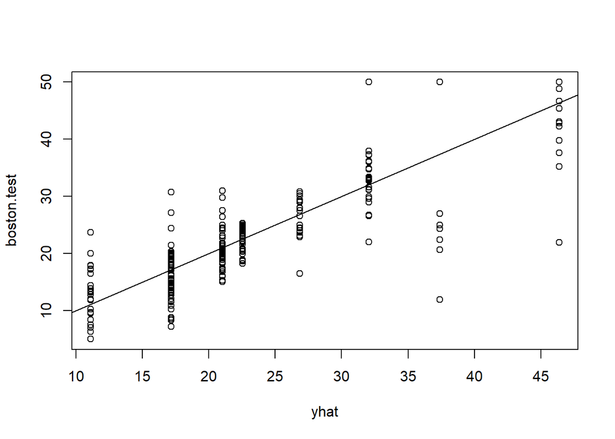

```r
yhat <- predict(tree.boston, newdata=Boston[-train,])
boston.test <- Boston[-train, "medv"]
plot(yhat, boston.test)
abline(0, 1)
```

```r
mean((yhat-boston.test)^2)
```

```
## [1] 25.04559
```

As shown above, the test set mean squared error associated with our regression tree is 25.05. The sqrt(MSE) is around 5.005, indicating that this model leads to test predictions that are within around $5,005 of the true median home value for the suburb.

## Bagging and Random Forests

Since bagging is a special case of a random forest where m = p, we can use the randomforest() function to perform both random forests and bagging.

```r
# r e p r o d u c i b i l i t y
set.seed(8)
# random forest function
# mtry=13 is the number of predictors considered for each split in the tree. Since we have 13 predictors, we are using bagging (m=p).
bag.boston <- randomForest(medv~., data=Boston, subset=train, mtry=13, importance=TRUE)
bag.boston
```

```
##
## Call:
##  randomForest(formula = medv ~ ., data = Boston, mtry = 13, importance = TRUE,      subset = train)
##                Type of random forest: regression
##                      Number of trees: 500
## No. of variables tried at each split: 13
##
##           Mean of squared residuals: 11.04833
##                     % Var explained: 86.62
```

Test set:

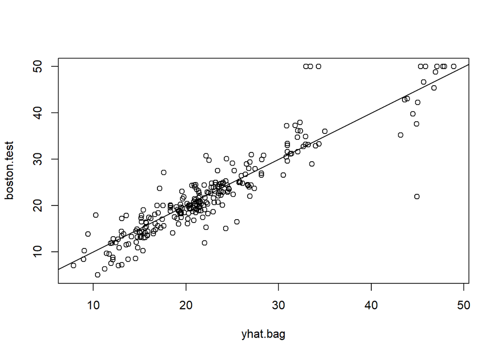

```r
yhat.bag <- predict(bag.boston, newdata=Boston[-train,])
plot(yhat.bag, boston.test)
abline(0,1)
```

```r
mean((yhat.bag-boston.test)^2)
```

```
## [1] 13.52586
```

The test set MSE associated with the bagged regression tree is 13.5, almost half of what we obtained using the optimally pruned single tree. We can change the number of trees grown by randomForest() using the ntree argument

```r
set.seed(3)
# bag restricted to 25 trees
bag.boston <- randomForest(medv~., data=Boston, subset=train, mtry=13, ntree=25)
# fit tree
yhat.bag <- predict(bag.boston, newdata=Boston[-train,])
# calc MSE
mean((yhat.bag-boston.test)^2)
```

```
## [1] 14.59052
```

When growing a random forest, all we need to do is change the mtry parameter. The default parameter of mtry is p/3 when building a randomForest out of regression trees and sqrt(p) variables when building a randomForest out of classification trees.

Here we create a random forest with mtry=6

```r
# reproducibility
set.seed(16)

# create randomForest
rf.boston <- randomForest(medv~., data=Boston, subset=train, mtry=6, importance=TRUE)
# fit model
yhat.rf <- predict(rf.boston, newdata=Boston[-train,])
# MSE
mean((yhat.rf-boston.test)^2)
```

```
## [1] 11.46028
```

Our MSE is 11.46, indicating an improvement over bagging for this case. Using the importance() function, we can view the importance of each variable.

```r
importance(rf.boston)
```

```
##           %IncMSE IncNodePurity
## crim    12.406695    1151.55948
## zn       3.608577      47.61137
## indus    9.724113    1169.89228
## chas     1.889658      32.35765
## nox     12.258745     981.64879
## rm      29.869689    6002.24710
## age     10.078007     562.87140
## dis     14.272678    1244.84513
## rad      3.959835     100.88828
## tax      8.490069     523.46262
## ptratio 10.776262     951.01953
## black    7.753986     343.57532
## lstat   29.813628    7366.79871
```

Above, two measures of variable importance are reported. The first column represents the % increase in MSE, or the decrease in accuracy prediction when the given variable is excluded from the model. The second column indicates the decrease in node purity that results from splits over that variable, averaged over all trees.

We can plot these importance measures using the varImpPlot() function:

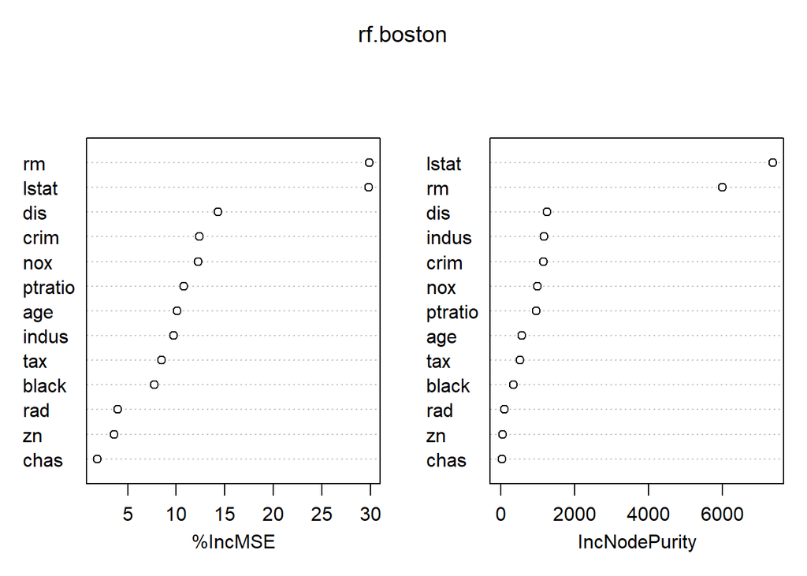

```r
varImpPlot(rf.boston)
```

These charts indicate that across all of the trees included in the random forest, the wealth level of the community (lstat) and the house size (rm) are by far the 2 most important variables.

## Boosting

We will use the gbm package, and within it, the gbm() function, to fit boosted regression trees to the Boston data set. We run gbm() with the option distribution=“gaussian” since this is a regression problem. If it were a binary classification problem, we would use distribution=“bernoulli”. The argument n.trees=5000 indicates we want 5000 trees and the option interaction.depth=4 limits the depth of each tree to 4 nodes.

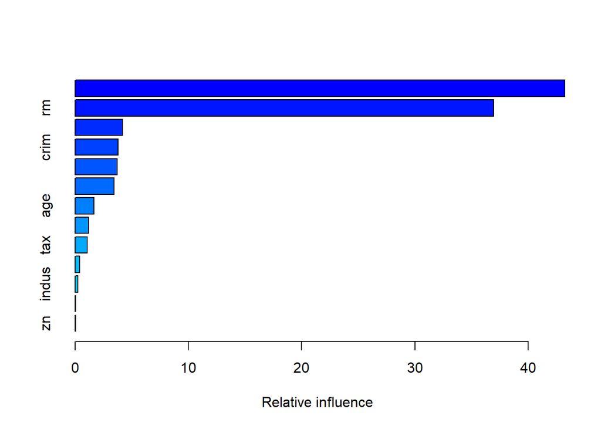

```
##             var     rel.inf
## lstat     lstat 43.23927553
## rm           rm 36.96791908
## dis         dis  4.18179441
## crim       crim  3.81220890
## ptratio ptratio  3.72845055
## nox         nox  3.43461982
## age         age  1.64984111
## black     black  1.17485059
## tax         tax  1.07399845
## rad         rad  0.40376456
## indus     indus  0.24574978
## chas       chas  0.05844202
## zn           zn  0.02908520
```

```r
# reproducibility
set.seed(24)
# boosting function
boost.boston <- gbm(medv~., data=Boston[-train,], distribution = "gaussian", n.trees = 5000, interaction.depth = 4)
# summary
summary(boost.boston)
```

We see from the summary above that lstat and rm are the most important variables by a lot. We can also produce partial dependence plots for these two variables.

Partial Dependence Plots illustrate the marginal effect of the selected variables on the response after integrating out the other variables.

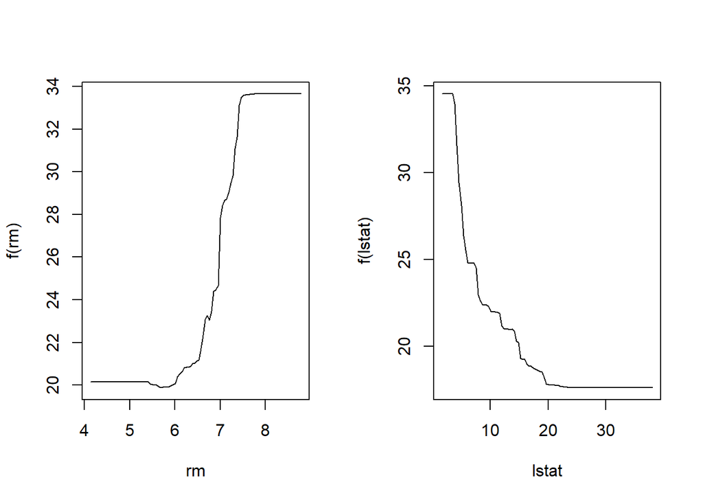

```r
par(mfrow=c(1,2))
plot(boost.boston, i="rm")
plot(boost.boston, i="lstat")
```

In this case, median housing prices are increasing with rm and decreasing with lstat.

We can now use the boosted model to predict medv on the test set:

```r
yhat.boost <- predict(boost.boston, newdata = Boston[-train ,],
n.trees = 5000)
mean((yhat.boost-boston.test)^2)
```

```
## [1] 6.425612
```

```r
# boost function with lambda shrinkage parameter
boost.boston <- gbm(medv~., data=Boston[train,], distribution = "gaussian", n.trees = 5000, interaction.depth = 4, shrinkage = 0.2, verbose = F)
# fit
yhat.boost <- predict(boost.boston, newdata=Boston[-train,], n.trees=5000)
# MSE
mean((yhat.boost-boston.test)^2)
```

```
## [1] 11.79795
```